# Data Visualization 2

Joel Ledford

Winter 2019

## Review

Now that you have been introduced to `ggplot`, we need to practice a few more plot types and learn how to manipulate the aesthetics of plots to better suit our needs. Aesthetics can make a significant difference visually, but you can take it too far so remember that our goal is to produce clean plots that are not too distracting.

## Resources

- [ggplot2 cheatsheet](https://www.rstudio.com/wp-content/uploads/2015/03/ggplot2-cheatsheet.pdf)
- [R for Data Science](https://r4ds.had.co.nz/)
- [R Cookbook](http://www.cookbook-r.com/)

## Load the libraries

```r
library(tidyverse)
library(skimr)
```

### Box Plots

Let’s briefly return to the `homerange` data and filter out carnivorous mammals. We can use a boxplot to visualize the differences in body mass by family.

```r
homerange <-
  readr::read_csv("data/Tamburelloetal_HomeRangeDatabase.csv")
```

```r
carni_mammals <-
  homerange %>%
  filter(taxon=="mammals", trophic.guild=="carnivore")
carni_mammals
```

```
## # A tibble: 80 x 24
##    taxon common.name class order family genus species primarymethod N
##    <chr> <chr>       <chr> <chr> <chr>  <chr> <chr>   <chr>         <chr>
##  1 mamm… giant gold… mamm… afro… chrys… chry… trevel… telemetry*    <NA>
##  2 mamm… Grant's go… mamm… afro… chrys… erem… granti  telemetry*    <NA>
##  3 mamm… arctic fox  mamm… carn… canid… alop… lagopus telemetry*    <NA>
##  4 mamm… Ethiopian … mamm… carn… canid… canis simens… telemetry*    <NA>
##  5 mamm… culpeo      mamm… carn… canid… pseu… culpae… telemetry*    <NA>
##  6 mamm… South Amer… mamm… carn… canid… pseu… griseus telemetry*    <NA>
##  7 mamm… kit fox     mamm… carn… canid… vulp… macroti telemetry*    <NA>
##  8 mamm… Ruppel's f… mamm… carn… canid… vulp… ruppel… telemetry*    <NA>
##  9 mamm… swift fox   mamm… carn… canid… vulp… velox   telemetry*    <NA>
## 10 mamm… fossa       mamm… carn… euple… cryp… ferox   telemetry*    <NA>
## # … with 70 more rows, and 15 more variables: mean.mass.g <dbl>,
## #   log10.mass <dbl>, alternative.mass.reference <chr>, mean.hra.m2 <dbl>,
## #   log10.hra <dbl>, hra.reference <chr>, realm <chr>,
## #   thermoregulation <chr>, locomotion <chr>, trophic.guild <chr>,
## #   dimension <chr>, preymass <dbl>, log10.preymass <dbl>, PPMR <dbl>,
## #   prey.size.reference <chr>
```

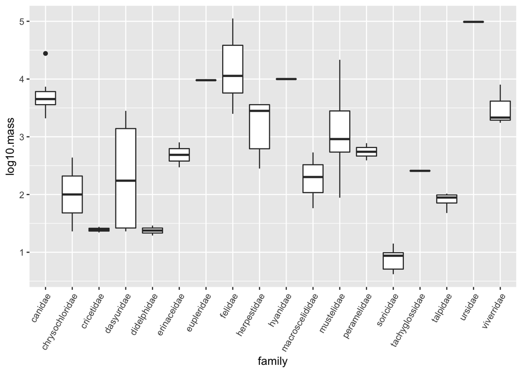

```r
carni_mammals %>%
  ggplot(aes(x=family, y=log10.mass))+
  geom_boxplot()+
  theme(axis.text.x = element_text(angle = 60, hjust=1))
```

## Practice

1. What do you think those solid lines represent in the box plot above? Use `count` to determine which families have the largest and smallest sample sizes.
2. Rebuild the plot only for the top five families with the largest sample sizes. How is `ggplot` ordering families on the x-axis?
3. There are more herbivores than carnivores in the homerange data, but how do their masses compare? Make a boxplot that compares their masses. Use `log10.mass`.

## Aesthetics: Labels

Now that we have practiced scatterplots, barplots, and boxplots we need to learn how to adjust their appearance to suit our needs. Let’s start with labelling x and y axes.

In this example, we explored the relationship between body mass and homerange.

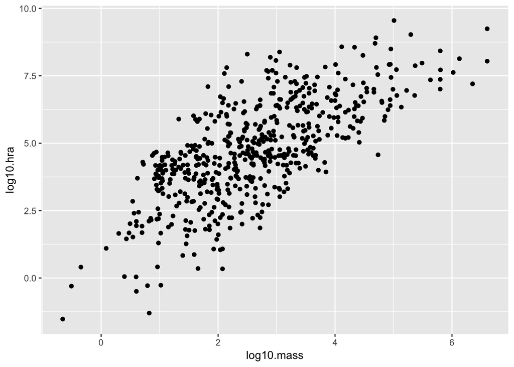

```r
ggplot(data=homerange, mapping=aes(x=log10.mass, y=log10.hra)) +
  geom_point()
```

The plot looks clean, but it is incomplete. A reader unfamiliar with the data might have a difficult time interpreting the plot with labels. To add labels, we use the `labs` command.

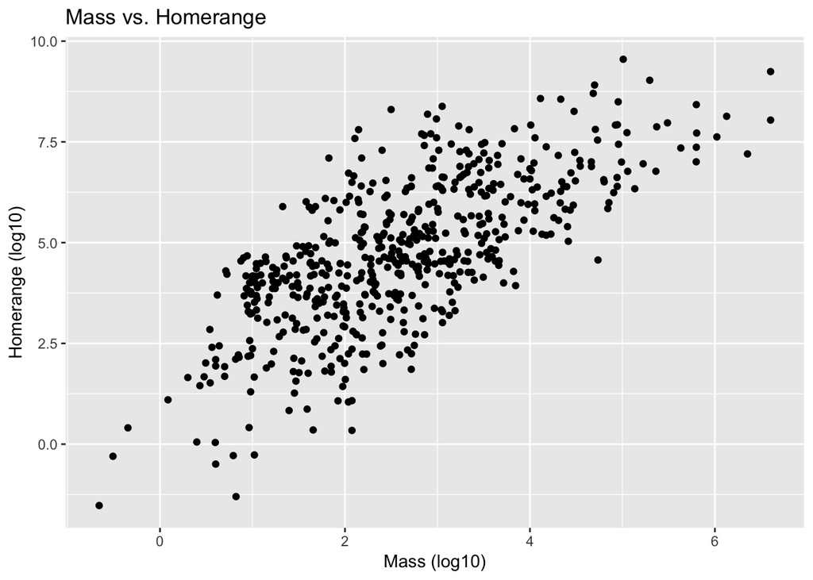

```r
ggplot(data=homerange, mapping=aes(x=log10.mass, y=log10.hra)) +
  geom_point()+
  labs(title = "Mass vs. Homerange",
       x = "Mass (log10)",
       y = "Homerange (log10)")
```

We can improve the plot further by adjusting the size and condition of the text.

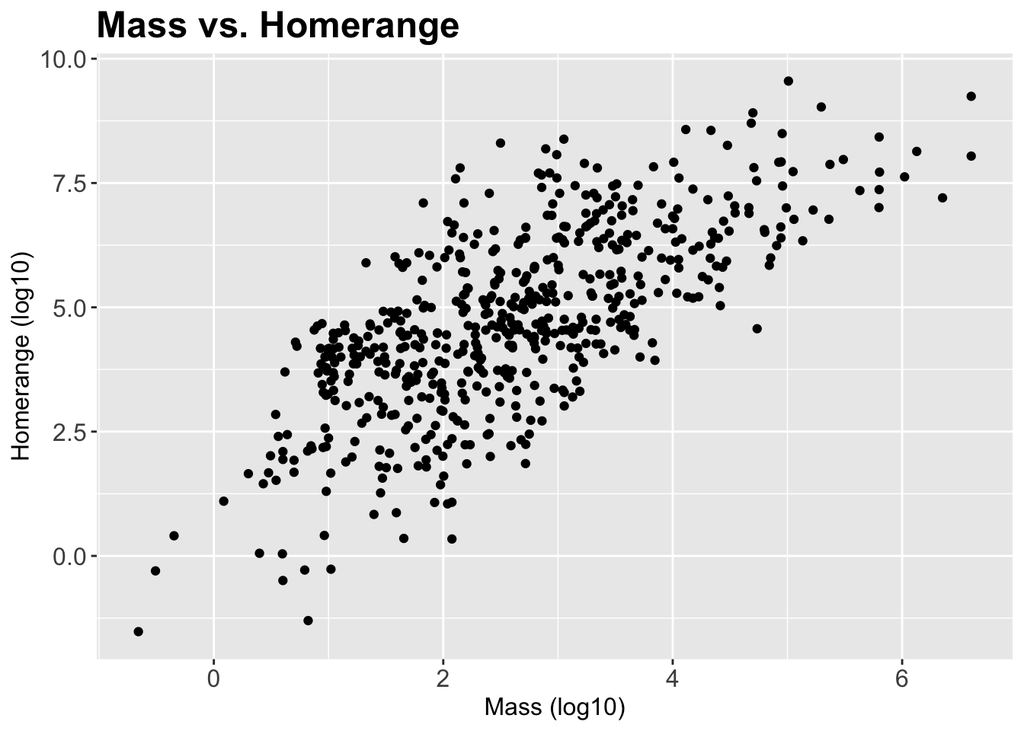

```r
ggplot(data=homerange, mapping=aes(x=log10.mass, y=log10.hra)) +
  geom_point()+
  labs(title = "Mass vs. Homerange",
       x = "Mass (log10)",
       y = "Homerange (log10)")+
  theme(plot.title=element_text(size=18, face="bold"),
        axis.text=element_text(size=12),
        axis.title=element_text(size=12))
```

The `rel` option changes the relative size of the title to keep things consistent. Adding `hjust` allows control of title position.

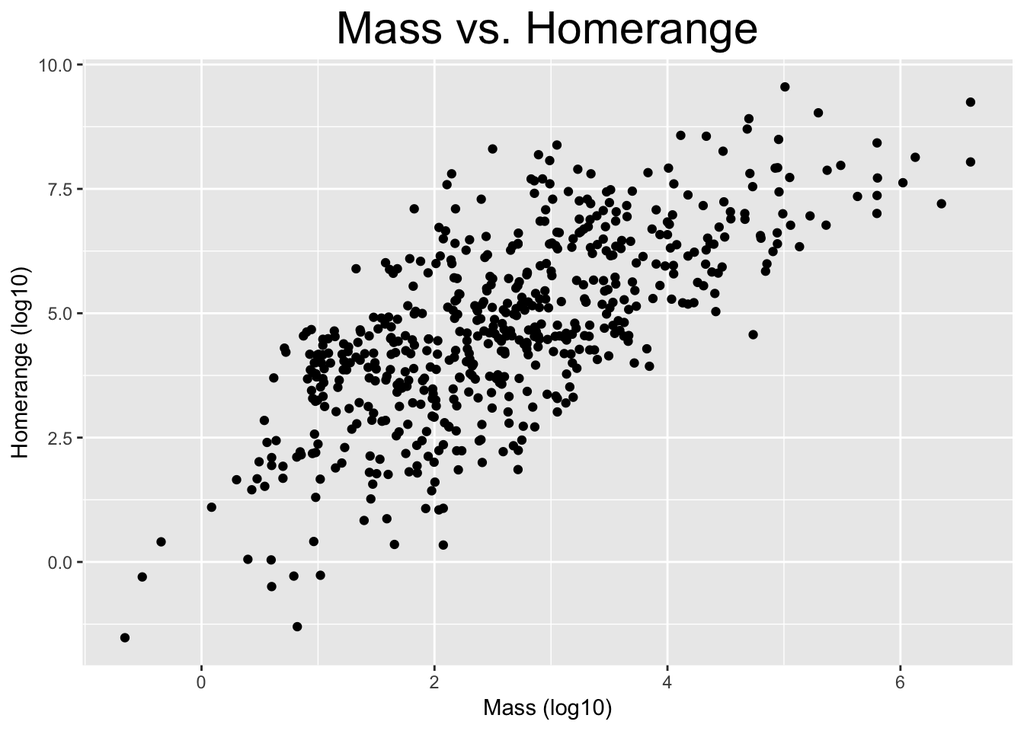

```r
ggplot(data=homerange, mapping=aes(x=log10.mass, y=log10.hra)) +
  geom_point()+
  labs(title = "Mass vs. Homerange",
       x = "Mass (log10)",
       y = "Homerange (log10)")+
  theme(plot.title = element_text(size = rel(2), hjust = 0.5))
```

## Practice

1. Make a plot that shows the number of individuals per locomotion type. Be sure to provide a title and label the axes appropriately.

## Other Aesthetics

There are lots of options for aesthtics. An aesthetic can be either numeric or categorical. `color` is a common option; notice that an appropriate key is displayed when you use one of the aesthetic options.

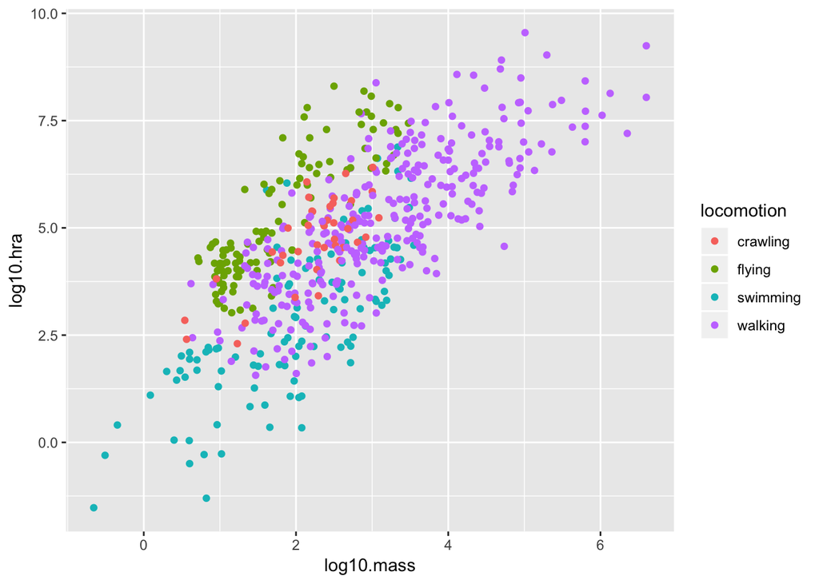

```r
homerange %>%
  ggplot(aes(x=log10.mass, y=log10.hra, color=locomotion))+
  geom_point()
```

`size` adjusts the size of points relative to a continuous variable.

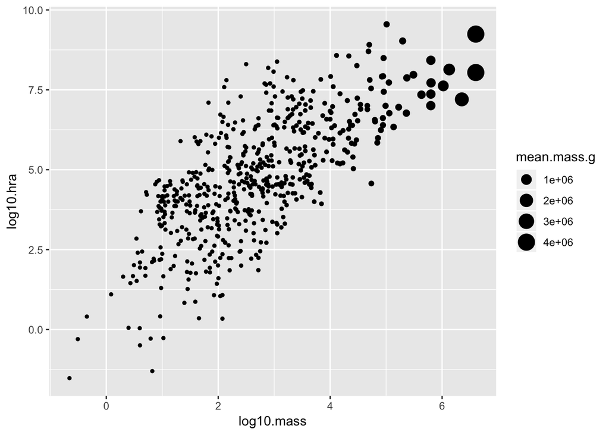

```r
homerange %>%
  ggplot(aes(x=log10.mass, y=log10.hra, size=mean.mass.g))+
  geom_point()
```

Here I am plotting `class` on the x-axis and `log10.mass` on the y-axis. I use `group` to make individual box plots for each taxon. I also use `fill` so I can associate the different taxa with a color coded key.

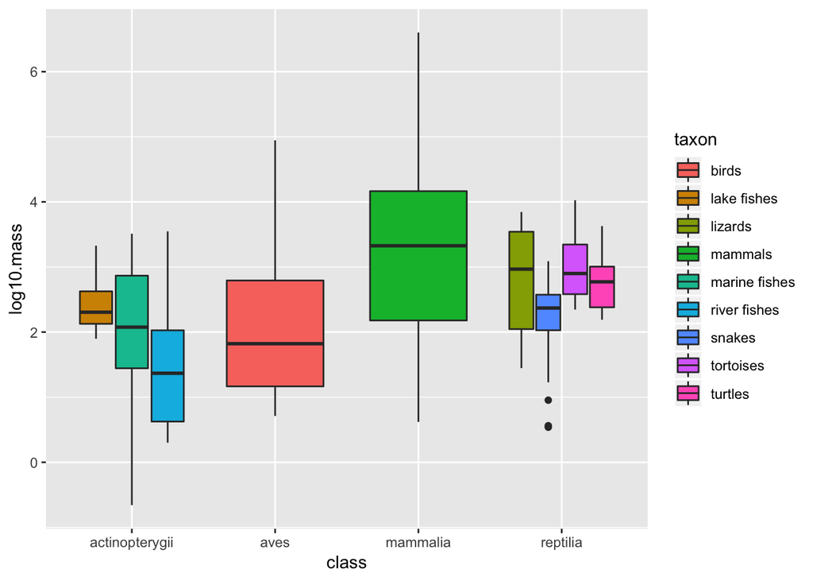

```r
homerange %>%
  ggplot(aes(x=class, y=log10.mass, group=taxon, fill=taxon))+
  geom_boxplot()
```

## Practice

1. Make a barplot that shows counts of ectotherms and endotherms. Label the axes, provide a title, and fill by thermoregulation type.
2. Make a boxplot that compares thermoregulation type by mog10.mass. group and fill by class. Label the axes and provide a title.

## Wrap-up

Please review the learning goals and be sure to use the code here as a reference when completing the homework.

See you next time!